# Tutorial17-more2DArrays

```python
import numpy as np
import matplotlib.pyplot as plt
```

```python
# I cannot figure out how to import my modules so I am just pasting the functions I need here
def describe(a):

    '''
    --------input-------
    a = np.array

    -------output----------

    The describe function [prints descriptions of the array a

    '''


    print(f"length is {len(a)}")
    print(f"size is {a.size}")
    print(f"shape is {a.shape}")
    print(f"number of dimensions is {a.ndim}")
    print(f"contents are...\n{a}")
    print(f"maximum value is {a.max()}")
    print(f"minimum value is {a.min()}")
```

## 2 think+type: astronomical images

```python
# importing the FITS files

# import a tool for reading FITS files
from astropy.io import fits

# open the FITS files, extract the data from their 0th extension
img1 = fits.open('stars1.fits')[0].data
img2 = fits.open('stars2.fits')[0].data
```

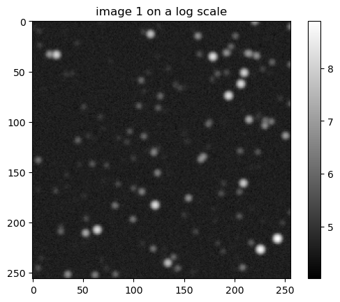

[figure not shown]

```python
#IDK why but the for loop wasn;t working for me so i just printed each image sepertly
plt.title("image 1 on a log scale")
plt.imshow(np.log(img1), cmap='gray')

plt.colorbar()

plt.show();

plt.title("image 2 on a log scale")
plt.imshow(np.log(img1), cmap='gray')

plt.colorbar()

plt.show();
```

Please note that I am unable to spot the asteroid. This is most likely because of my visual impairment. I need to allow each photo to take up my whole screen to even see the stars so it is impossible for me to compare the two images with my eyes. I am positive I could write code to compare the two arrays and find the asteroid that way. But, that seems a bit extra for this step.

```python
print(f"{img1} \n \n \n end \n \n \n {img2}") #just making sure I imported everything correctly
```

```
[[ 92.80010028  86.92497827  96.5970828  ... 118.91384617 127.9049154
  108.52401223]
 [ 99.97014755 100.55742075 102.92538471 ... 105.23478364 128.91699386
  130.16929308]
 [113.5048081   99.59117208  80.96966186 ... 127.08309    169.45721837
  190.65547322]
 ...
 [130.95789671 114.97508541 105.72512209 ... 105.2156641   99.74157451
  109.79459047]
 [ 93.55924494 116.57385958  92.94528134 ...  93.61784743 101.30747382
  108.2808154 ]
 [100.59736257 101.19144643 103.95673312 ...  82.58303806  86.04708902
  117.8447799 ]]


 end


 [[ 97.08963272 106.12643699  92.07332465 ...  91.1836787  102.33751316
  122.95788182]
 [ 97.40000973  90.45188486  96.89703065 ... 130.37703496 121.75941991
  132.91878035]
 [103.13386245  85.90949826 128.27572196 ... 134.39695356 153.58513261
  203.74669952]
 ...
 [ 99.55804114 127.72701794  99.94775968 ...  94.90387917 100.65738244
   79.71894421]
 [103.67122327  96.68904499  87.3756863  ...  99.06146014  94.53837275
  104.51372   ]
 [ 96.29222026  98.90509913  90.55651921 ... 100.59974577 107.75266731
   98.37114386]]
```

```python
count = 1
for image in [img1, img2]:

    # imshow each image
    plt.imshow(np.log(image), cmap='gray')
    # add a colorbar for each image
    plt.colorbar()
    # adds a title for each image, I'm using a counter variable to know which image I am pritning to add the appriopriuate title
    if count == 1:
        plt.title("img 1")
    elif count == 2:
        plt.title("img 2")
    # actually draw the imshow for each image
    plt.show();

    print(count)
    count += 1 # counter variable for the title of the images
```

[output not shown]

## 3 think+pair+code: find the asteroid

#### I did this part by myself at home

To find the asteroid, I am planning on looping through every element in each array and testing if they are the same

```python
#checking to make sure each array is the same length
print(f" the two arrays have the same number of rows, {len(img1) == len(img2)}") # testing if the two arrays have the same number of rows

print(f"\n \n  the two arrays have the same number of columns, {len(img1[0]) == len(img2[0])}") # testing if the two arrays have the same number of columns

# ok, I know I could have checked that easier by comparing both arrays' shapes
print(np.shape(img1) == np.shape(img2))
```

```python
for i in range(len(np.shape(img1)[0])): #running through all the rows
    for j in range(np.shape(img1)[1])): #running through all of the columns
        if img1[i][j] == img2[i][j]:
            pass
        else:
            print(f" row = {i}, column = {j}")
```

```python
img1[0][0] == img2[0][0] # testing to see if I can even compare them pixel by pixel
```

```python
img1[127][127] == img2[127][127] #testing again to see if I did something incoorect or got a falsde positve
```

```python
describe(img1)
```

```python
img1[0][0]
```

```python
img2[0][0]
```

```python
img1[0][255]
```

```python
img2[0][255]
```

```python
int(str(img1[0][0])[0]) #conveerting img1[0][0] to a string to accsses only the firsdt digit then back to an integer

int(str(img1[0][0])[0]) == int(str(img2[0][0])[0]) #if I did everything correvtly this should return, True
```

```python
for i in range(10): #testing if this will work because when I ran, for j in range(np.shape(img1)[0]) my jupyter notebook crashed
    for j in range(10): #running through all of the columns
        if int(str(img1[i][j])[0]) == int(str(img2[i][j])[0]):
            pass
        else:
            print(f" row = {i}, column = {j}")
            print(f" img1 = {int(str(img1[i][j])[0])} img2 = {int(str(img2[i][j])[0])}")
```

```
 row = 0, column = 1
 img1 = 8 img2 = 1
 row = 0, column = 6
 img1 = 8 img2 = 1
 row = 0, column = 8
 img1 = 8 img2 = 9
 row = 0, column = 9
 img1 = 1 img2 = 9
 row = 1, column = 1
 img1 = 1 img2 = 9
 row = 1, column = 2
 img1 = 1 img2 = 9
 row = 1, column = 3
 img1 = 1 img2 = 9
 row = 1, column = 6
 img1 = 9 img2 = 1
 row = 1, column = 8
 img1 = 1 img2 = 9
 row = 1, column = 9
 img1 = 9 img2 = 8
 row = 2, column = 1
 img1 = 9 img2 = 8
 row = 2, column = 2
 img1 = 8 img2 = 1
 row = 2, column = 3
 img1 = 1 img2 = 8
 row = 2, column = 4
 img1 = 8 img2 = 1
 row = 2, column = 5
 img1 = 9 img2 = 1
 row = 2, column = 6
 img1 = 9 img2 = 8
 row = 2, column = 8
 img1 = 1 img2 = 9
 row = 3, column = 0
 img1 = 1 img2 = 9
 row = 3, column = 2
 img1 = 9 img2 = 1
 row = 3, column = 3
 img1 = 1 img2 = 9
```

[output cut: 23 more lines]

```
 img1 = 1 img2 = 8
 row = 5, column = 9
 img1 = 1 img2 = 8
 row = 6, column = 5
 img1 = 1 img2 = 9
 row = 6, column = 6
 img1 = 9 img2 = 1
 row = 6, column = 8
 img1 = 8 img2 = 9
 row = 6, column = 9
 img1 = 1 img2 = 9
 row = 7, column = 8
 img1 = 1 img2 = 9
 row = 7, column = 9
 img1 = 9 img2 = 1
```

The code in [119] didn't work as way too frequently, the first digit of img1[row][column] was different than the first digit of img2[row][column]

```python
for i in range(10): #testing if this will work because when I ran, for j in range(np.shape(img1)[0]), my Jupyter notebook crashed
    for j in range(10): #running through all of the columns
        difference = int(np.abs(img1[i][j] - img2[i][j])) # calculating the absolute value of the difference between the pixels of the two images
        if difference < 30:
            pass
        else:
            print(f" row = {i}, column = {j}")
            print(f" the difference between img1 and img2 is, {difference}")
```

```
 row = 2, column = 2
 the difference between img1 and img2 is, 47
 row = 3, column = 6
 the difference between img1 and img2 is, 30
 row = 7, column = 1
 the difference between img1 and img2 is, 32
 row = 7, column = 2
 the difference between img1 and img2 is, 35
 row = 9, column = 5
 the difference between img1 and img2 is, 33
```

ok, so the code in [121] has definitely produced a short output that the code in [119]. So the question now is, what difference should I test the whole array with?

I am thinking for efficiency's sake, to start off with, difference < 100 in my first run through of the whole array. This will point out major points of interest. If none are found using difference < 100, then I will decrease what differnece needs to be larger than.

```python
for i in range(np.shape(img1)[0]): #running through all the rows
    for j in range(np.shape(img1)[1]): #running through all of the columns
        difference = int(np.abs(img1[i][j] - img2[i][j])) # calculating teh absolute value of the difference between the pixels of the two images
        if difference < 100:
            pass
        else:
            print(f" row = {i}, column = {j}")
            print(f" the difference between img1 and img2 is, {difference}")
```

```
 row = 33, column = 215
 the difference between img1 and img2 is, 145
 row = 35, column = 26
 the difference between img1 and img2 is, 135
 row = 35, column = 178
 the difference between img1 and img2 is, 103
 row = 36, column = 176
 the difference between img1 and img2 is, 115
 row = 36, column = 180
 the difference between img1 and img2 is, 155
 row = 37, column = 179
 the difference between img1 and img2 is, 116
 row = 37, column = 181
 the difference between img1 and img2 is, 105
 row = 51, column = 212
 the difference between img1 and img2 is, 139
 row = 52, column = 211
 the difference between img1 and img2 is, 152
 row = 53, column = 209
 the difference between img1 and img2 is, 155
 row = 63, column = 206
 the difference between img1 and img2 is, 350
 row = 64, column = 207
 the difference between img1 and img2 is, 103
 row = 73, column = 197
 the difference between img1 and img2 is, 172
 row = 74, column = 195
 the difference between img1 and img2 is, 150
 row = 76, column = 195
 the difference between img1 and img2 is, 111
 row = 103, column = 231
 the difference between img1 and img2 is, 112
 row = 130, column = 200
 the difference between img1 and img2 is, 124
 row = 130, column = 201
 the difference between img1 and img2 is, 139
 row = 130, column = 202
 the difference between img1 and img2 is, 116
 row = 131, column = 199
 the difference between img1 and img2 is, 111
```

[output cut: 193 more lines]

```
 the difference between img1 and img2 is, 141
 row = 224, column = 225
 the difference between img1 and img2 is, 101
 row = 225, column = 229
 the difference between img1 and img2 is, 111
 row = 226, column = 227
 the difference between img1 and img2 is, 163
 row = 227, column = 222
 the difference between img1 and img2 is, 105
 row = 228, column = 223
 the difference between img1 and img2 is, 136
 row = 228, column = 224
 the difference between img1 and img2 is, 108
 row = 229, column = 229
 the difference between img1 and img2 is, 104
```

This is still too much data, but it is significantly better than the original way I did this. I will be changing to differeence < 200

```python
for i in range(np.shape(img1)[0]): #running through all the rows
    for j in range(np.shape(img1)[1]): #running through all of the columns
        difference = int(np.abs(img1[i][j] - img2[i][j])) # calculating teh absolute value of the difference between the pixels of the two images
        if difference < 200:
            pass
        else:
            print(f" row = {i}, column = {j}")
            print(f" the difference between img1 and img2 is, {difference}")
```

```
 row = 63, column = 206
 the difference between img1 and img2 is, 350
 row = 131, column = 201
 the difference between img1 and img2 is, 253
 row = 131, column = 202
 the difference between img1 and img2 is, 234
 row = 132, column = 199
 the difference between img1 and img2 is, 207
 row = 132, column = 200
 the difference between img1 and img2 is, 310
 row = 132, column = 201
 the difference between img1 and img2 is, 398
 row = 132, column = 202
 the difference between img1 and img2 is, 377
 row = 132, column = 203
 the difference between img1 and img2 is, 253
 row = 132, column = 204
 the difference between img1 and img2 is, 206
 row = 133, column = 199
 the difference between img1 and img2 is, 249
 row = 133, column = 200
 the difference between img1 and img2 is, 400
 row = 133, column = 201
 the difference between img1 and img2 is, 465
 row = 133, column = 202
 the difference between img1 and img2 is, 489
 row = 133, column = 203
 the difference between img1 and img2 is, 376
 row = 134, column = 199
 the difference between img1 and img2 is, 229
 row = 134, column = 200
 the difference between img1 and img2 is, 348
 row = 134, column = 201
 the difference between img1 and img2 is, 456
 row = 134, column = 202
 the difference between img1 and img2 is, 452
 row = 134, column = 203
 the difference between img1 and img2 is, 339
 row = 134, column = 204
 the difference between img1 and img2 is, 205
```

[output cut: 49 more lines]

```
 the difference between img1 and img2 is, 340
 row = 171, column = 110
 the difference between img1 and img2 is, 259
 row = 172, column = 107
 the difference between img1 and img2 is, 204
 row = 172, column = 108
 the difference between img1 and img2 is, 231
 row = 172, column = 109
 the difference between img1 and img2 is, 231
 row = 184, column = 121
 the difference between img1 and img2 is, 230
 row = 214, column = 243
 the difference between img1 and img2 is, 223
 row = 216, column = 241
 the difference between img1 and img2 is, 208
```

Ok again improvement, but still not refined enough. I will now be switching to difference is less than 400

```python
for i in range(np.shape(img1)[0]): #running through all the rows
    for j in range(np.shape(img1)[1]): #running through all of the columns
        difference = int(np.abs(img1[i][j] - img2[i][j])) # calculating teh absolute value of the difference between the pixels of the two images
        if difference < 400:
            pass
        else:
            print(f" row = {i}, column = {j}")
            print(f" the difference between img1 and img2 is, {difference}")
```

```
 row = 133, column = 200
 the difference between img1 and img2 is, 400
 row = 133, column = 201
 the difference between img1 and img2 is, 465
 row = 133, column = 202
 the difference between img1 and img2 is, 489
 row = 134, column = 201
 the difference between img1 and img2 is, 456
 row = 134, column = 202
 the difference between img1 and img2 is, 452
 row = 169, column = 107
 the difference between img1 and img2 is, 422
 row = 169, column = 108
 the difference between img1 and img2 is, 453
 row = 169, column = 109
 the difference between img1 and img2 is, 440
 row = 170, column = 107
 the difference between img1 and img2 is, 407
 row = 170, column = 108
 the difference between img1 and img2 is, 482
 row = 170, column = 109
 the difference between img1 and img2 is, 440
```

Ok, well, this is good! I now have essentially two points on the image. The first point is around row 133, column 201, and the second point is around row 170 and column 108.

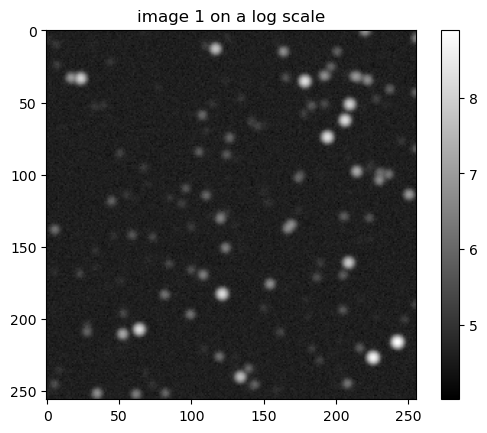

[figure not shown]

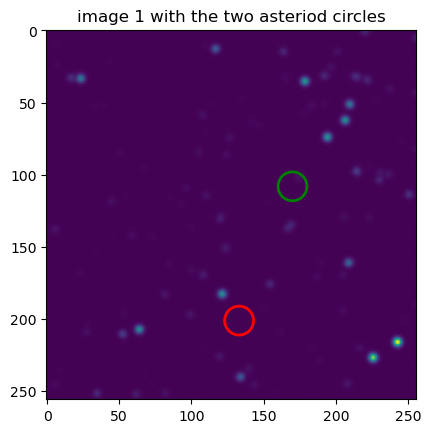

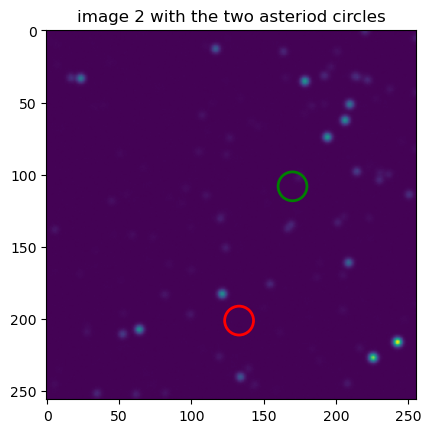

```python
#the two orginal plots of the images
plt.title("image 1 on a log scale")
plt.imshow(np.log(img1), cmap='gray')

plt.colorbar()

plt.show();

plt.title("image 2 on a log scale")
plt.imshow(np.log(img1), cmap='gray')

plt.colorbar()

plt.show();


# This is all from Google, the Google search, "how to draw a circle on an image in matplotlib.pyplot" as I did not know how to draw circles on images
import matplotlib.patches as patches
#creating a figure and axes

#creating a for loop to plot both images
for i in range(2):
    if i == 0: # plotting image 1 with the two circles
        fig, ax = plt.subplots(1)
        ax.imshow(img1)
        plt.title("image 1 with the two asteriod circles")

        asteriod_one = (133, 201) # defines roughly where the asteroid is at position 1
        asteriod_radius_one = 10       # this looks to be about the size of the asteroid
        asteriod_1 = patches.Circle(asteriod_one, asteriod_radius_one, edgecolor='red', facecolor='none', linewidth=2)
        ax.add_patch(asteriod_1)


        asteriod_two = (170, 108) # defines roughly where the asteroid is at position 1
        asteriod_radius_two = 10       # this looks to be about the size of the asteroid
        asteriod_2 = patches.Circle(asteriod_two, asteriod_radius_two, edgecolor='green', facecolor='none', linewidth=2)


        ax.add_patch(asteriod_2)


    elif i ==1: # plotting the 2nd image img 2 with the asteriod circles
        fig, ax = plt.subplots(1)
        ax.imshow(img2)
        plt.title("image 2 with the two asteriod circles")

        asteriod_one = (133, 201) # defines roughly where the asteroid is at position 1
        asteriod_radius_one = 10       # this looks to be about the size of the asteroid
        asteriod_1 = patches.Circle(asteriod_one, asteriod_radius_one, edgecolor='red', facecolor='none', linewidth=2)
        ax.add_patch(asteriod_1)


        asteriod_two = (170, 108) # defines roughly where the asteroid is at position 1
        asteriod_radius_two = 10       # this looks to be about the size of the asteroid
        asteriod_2 = patches.Circle(asteriod_two, asteriod_radius_two, edgecolor='green', facecolor='none', linewidth=2)


        ax.add_patch(asteriod_2)

        # I do not know why there is a purple filter on both images with the circles
```

I probably should have stayed longer in class yesterday to work with someone who is not visually impaired and could use their eyes to check if their code found the asteroid.